# Clifton Public School District — NJ School Data Almanac – NJ District Profiles

NJ School Data Almanac

Clifton Public School District

PASSAIC COUNTY · TRADITIONAL PUBLIC DISTRICT · DFG CD · 10,673 STUDENTS (2026)

10,673

Students

89.5%

4-yr grad rate

38.4%

Gr 3-8 ELA

16.6%

Chronically absent

$17,120

Per pupil

*10 things the data says about Clifton Public School District. Every figure is computed from New Jersey Department of Education data via the njschooldata package — nothing is estimated. Comparisons use District Factor Group (DFG) peers (67 districts in DFG CD).*

No. 1 ACHIEVEMENT

## Clifton’s Elementary ELA Proficiency Fell to 38.4% in 2024, Lower Than at the Bottom of the Pandemic

That 2024 figure is the lowest in the available record, below even the 39.2 percent measured at the depth of the pandemic disruption. It also sits below where Clifton stood in 2017, the earliest year of data, when 46.9 percent of grade 3-8 students were proficient in ELA. Math followed a milder version of the same arc, sliding from 41.6 percent proficient in 2019 to 29.8 percent in 2022 before a partial recovery to 32.0 percent in 2024.

The contrast with Clifton’s high school results is striking: over the same window, the district’s four-year graduation rate and its NJGPA scores rose, while its youngest tested students lost ground. What is keeping elementary and middle-grade reading from recovering even as the high school improves?

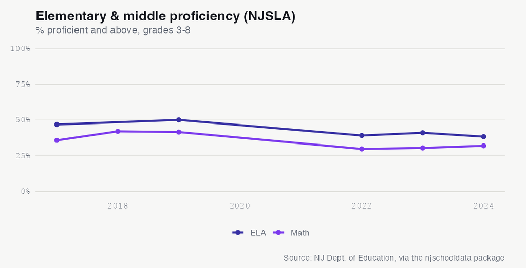

See the underlying data ›

No. 2 EQUITY

## A 53-Point Reading Gap Divides Clifton’s Asian Students From Its English Learners

In 2024, 59.8 percent of Asian grade 3-8 students were proficient in ELA, compared with 6.9 percent of students currently learning English.

Behind Clifton’s 38.4 percent district-wide ELA proficiency in grades 3-8 lies one of the widest subgroup spreads in its data. Asian students reached 59.8 percent proficiency in 2024, the highest of any group. Students who are currently English learners reached 6.9 percent, the lowest. That is a gap of nearly 53 points between two sets of children sitting for the same test.

The pattern holds across the rest of the rankings. White students were proficient at 46.7 percent and students who are not economically disadvantaged at 49.2 percent, while students who are economically disadvantaged came in at 31.6 percent, Hispanic students at 33.0 percent, and Black students at 35.2 percent. Students in special education registered 10.4 percent proficiency. The groups at the bottom of this list, English learners and students with disabilities, are among the fastest-growing in the district.

These are the early grades, where reading gaps either close or harden into the achievement differences that show up later in graduation data. As Clifton’s English-learner population climbs past 1,400 students, can the district lift reading proficiency for the groups starting furthest behind?

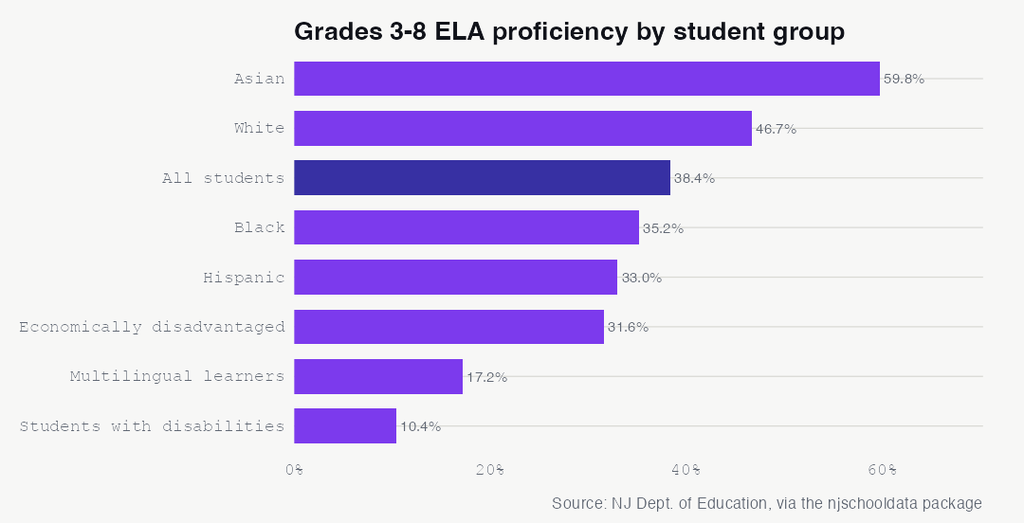

See the underlying data ›

No. 3 DEMOGRAPHICS

## Two-Thirds of Clifton Students Now Qualify for Subsidized Meals, Up From 57% in 2015

The share of students eligible for free or reduced-price lunch reached 69.5 percent in 2026, the highest in the available record.

Economic need has deepened in Clifton’s classrooms. In 2015, 57.1 percent of students, about 6,190 children, qualified for free or reduced-price lunch. By 2026 that share had risen to 69.5 percent, or 7,418 students, the highest level in the available data and an increase of more than 1,200 qualifying students.

The increase was not smooth. The eligible share dipped to 51.2 percent in 2022 before climbing sharply to 64.4 percent in 2023 and continuing upward through 2026, a swing that may reflect changes in how meal eligibility was counted during and after the pandemic. Even accounting for that volatility, the long-run direction is clearly upward, and it tracks a parallel rise in students learning English, who grew from 630 in 2015 to 1,441 in 2026.

Deepening poverty often shows up first in the early grades, where Clifton’s economically disadvantaged students were proficient in reading at 31.6 percent in 2024, well below the district’s better-off students. As the share of students who are economically disadvantaged approaches 70 percent, how will the district align resources with a population facing more economic pressure than a decade ago?

See the underlying data ›

No. 4 DEMOGRAPHICS

## Clifton’s Hispanic Enrollment Climbed From 53% to 63% Since 2015, as the White Share Fell 9 Points

The Passaic County district’s largest demographic shift over the past decade reshaped a student body that was already majority-Hispanic.

Clifton Public Schools was already a majority-Hispanic district in 2015, when 53.1 percent of its roughly 10,800 students were Hispanic. By 2026, that share had grown to 63.1 percent, a 10-point increase that is the single largest demographic change the district has recorded over the period.

The rise in Hispanic enrollment moved in near-lockstep with a decline in the white share, which fell from 34.7 percent in 2015 to 25.5 percent in 2026, a drop of 9.3 points. The Asian share slipped more modestly, from 7.0 percent to 5.6 percent, while the Black share held roughly steady near 3.6 to 4.9 percent. The multiracial category, though small, grew steadily from 0.2 percent to 1.5 percent.

These shifts came even as the district’s total enrollment barely moved, ending 2026 at 10,673 students, down just 1.5 percent from 2015. The composition changed far more than the size. As the student body grows more concentrated in one demographic group, how will Clifton tailor instruction, staffing, and family outreach to match who its families are today?

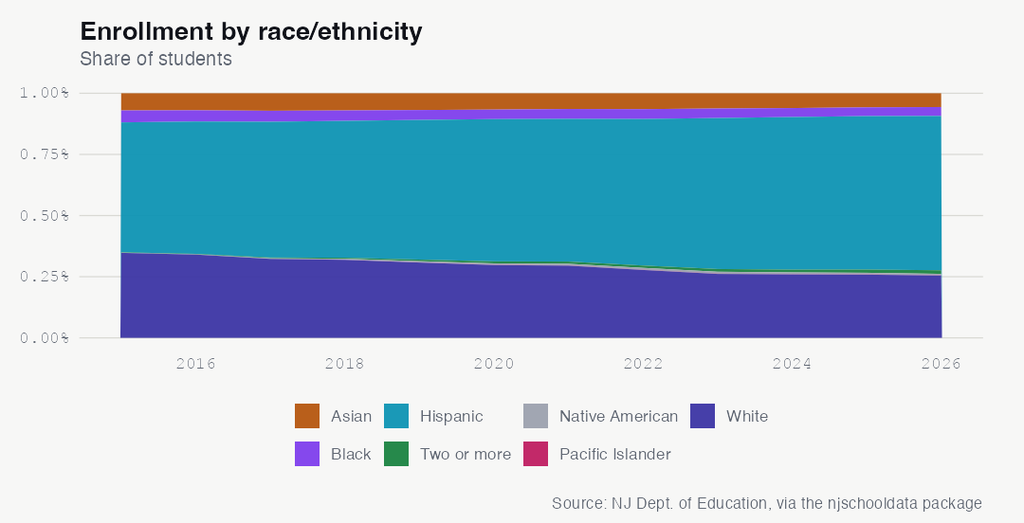

See the underlying data ›

No. 5 GRADUATION

## Clifton’s Graduation Rate Hit a Six-Year High of 89.5% in 2025, Still Below the DFG Peer Median

The four-year rate rose more than six points from its 2022 low, but it ranks in the 28th percentile among Clifton’s 67 District Factor Group peers.

Clifton’s four-year graduation rate has been on a clear upswing. After dipping to 83.3 percent in 2022, the rate climbed to 84.3 percent in 2023, 86.7 percent in 2024, and 89.5 percent in 2025, its highest mark in the six years of available data. The 2025 graduating cohort was also the largest at 854 students.

The improvement is real, but Clifton still trails its peer group. Its 89.5 percent rate places it in the 28th percentile among the 67 districts in District Factor Group CD, whose peer median sits at 91.9 percent, more than two points higher. Clifton is closing the distance, but it has not yet caught the middle of the pack.

The gain came as the district served a student body with rising poverty and a growing share of English learners, populations that often face steeper paths to graduation. If the recent momentum holds, how soon could Clifton’s rate reach or pass the peer median it has been chasing?

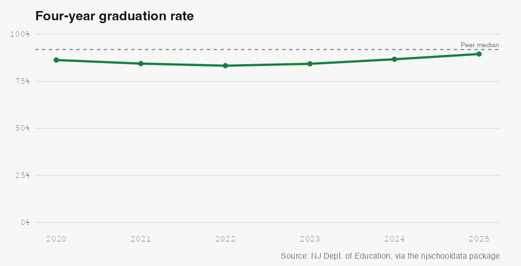

See the underlying data ›

No. 6 EQUITY

## A 21-Point Graduation Gap Separates Clifton’s Asian and Special-Education Students

Asian students graduated at 97.9 percent in 2025 while students with disabilities graduated at 76.6 percent, the widest subgroup spread in the district.

Clifton’s overall graduation rate of 89.5 percent in 2025 masks a wide spread across student groups. Asian students graduated at 97.9 percent, the highest of any subgroup, while students with disabilities graduated at 76.6 percent, the lowest, a gap of more than 21 points.

Between those poles, white students graduated at 92.9 percent and Black students at 88.6 percent, a difference of about four points. Hispanic students, who make up the largest share of the cohort at 551 graduates, finished at 87.7 percent, while students who are economically disadvantaged, the largest tracked group at 632 students, graduated at 88.0 percent. Multilingual learners reached 80.7 percent.

The district’s lowest-graduating groups, students with disabilities and multilingual learners, are precisely the populations that have grown in recent years. As Clifton’s overall rate rises, will the students furthest from the finish line share equally in the gains?

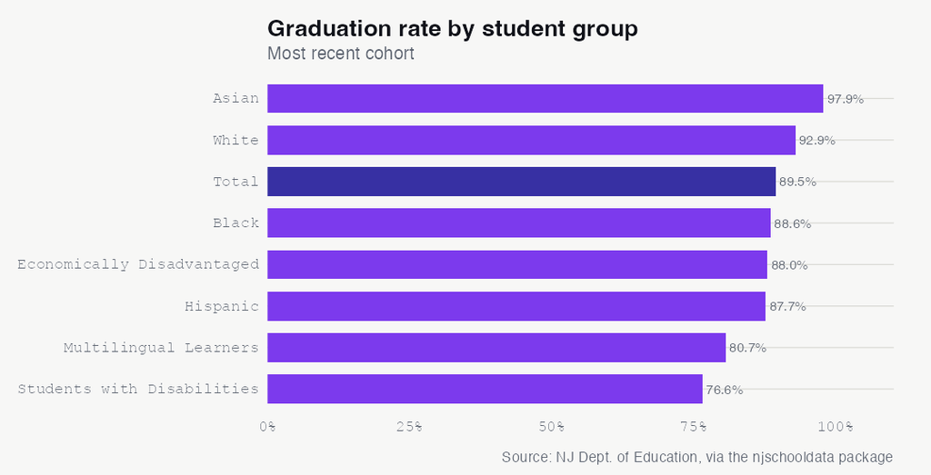

See the underlying data ›

No. 7 ACHIEVEMENT

## Clifton’s NJGPA Math Proficiency Jumped 7 Points to 46.1% in One Year

High-school math proficiency rose from 39.0 percent in 2024 to 46.1 percent in 2025, even as elementary math stalled.

Clifton’s high-school math results on the New Jersey Graduation Proficiency Assessment took a notable step up in 2025. The share of students scoring proficient or above in math climbed from 39.0 percent in 2024 to 46.1 percent in 2025, a gain of about seven points after the rate had hovered near 38 to 39 percent in the two prior years. English language arts also improved, rising from 71.6 percent proficient in 2024 to 74.2 percent in 2025.

The high-school gain stands in contrast to the district’s younger grades, where grade 3-8 math proficiency sat at just 32.0 percent in 2024 and ELA at 38.4 percent. The students who passed the high-school test in 2025 entered school before the pandemic; the ones struggling on the elementary assessments are the cohorts who lived through it.

Even after the jump, fewer than half of Clifton’s tested high-schoolers reached proficiency in math, compared with roughly three in four in English. What drove the one-year math gain at the high school, and can it eventually reach the elementary grades that have not recovered?

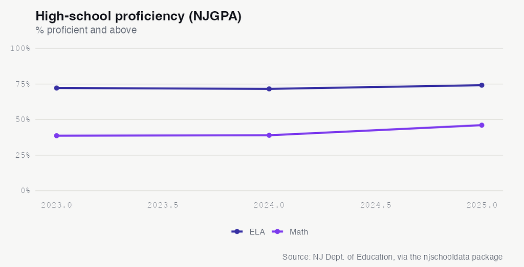

See the underlying data ›

No. 8 ATTENDANCE

## Chronic Absenteeism in Clifton Reached 16.6% in 2024, Above the Peer Median and 5 Points Over Pre-COVID

The share of students who are chronically absent has eased from its 2023 peak but remains well above where it stood before the pandemic.

Before the pandemic, 11.4 percent of Clifton students were chronically absent in 2019. By 2023 that share had surged to 18.9 percent before easing to 16.6 percent in 2024, still more than five points above the pre-COVID baseline.

Clifton’s 2024 rate also runs ahead of its peers. The District Factor Group CD median for chronic absenteeism sits at 14.6 percent, leaving Clifton two points higher than the typical district in its comparison group. The trajectory shows partial recovery: the rate climbed from a pandemic-era low of 9.3 percent in 2021 to 15.8 percent in 2022 and 18.9 percent in 2023 before the 2024 improvement.

Chronic absenteeism, defined as missing roughly a tenth or more of the school year, is closely tied to academic outcomes and may help explain why the district’s elementary test scores have been slow to rebound. With Clifton’s rate moving in the right direction but not yet back to its 2019 level, can the district close the remaining gap?

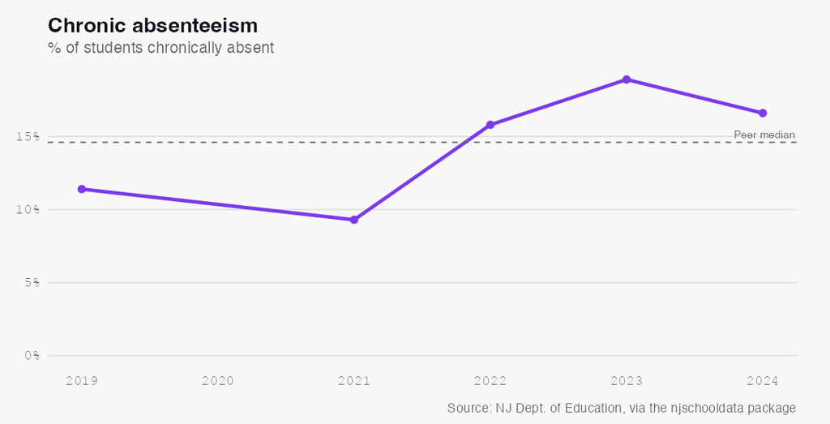

See the underlying data ›

No. 9 FINANCE

## Clifton Spent $17,120 Per Pupil in 2024, Up Nearly 50% Since 2014 but Below the Peer Median

Per-pupil spending grew 49.7 percent over a decade, yet still ranks in the 34th percentile among District Factor Group CD peers.

Clifton’s per-pupil spending rose from $11,436 in 2014 to $17,120 in 2024, an increase of 49.7 percent over the decade. The climb was steady, passing $13,000 by 2019, $15,000 by 2022, and approaching $17,000 by 2023.

Despite that growth, Clifton remains a relatively lean spender among similar districts. Its 2024 figure ranks in the 34th percentile among the 67 districts in District Factor Group CD, whose peer median is $18,350, more than $1,200 per student above Clifton. The district’s average daily enrollment held remarkably steady near 10,400 to 10,800 throughout the period, meaning the spending growth was not driven by shrinking enrollment.

Of every dollar Clifton spent in 2025, 58.7 percent went to classroom instruction, with 19.5 percent to support services and 9.1 percent to administration. As costs rise across New Jersey, can a district spending below its peer median keep pace with the needs of a student body that is increasingly low-income and multilingual?

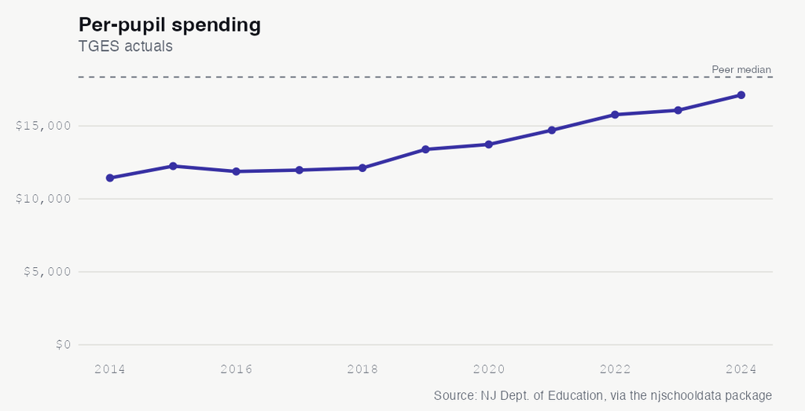

See the underlying data ›

No. 10 COLLEGE READINESS

## Clifton’s SAT Participation Fell From 69.7% to 27.8%, Now Less Than Half the State Rate

The share of eligible students taking the SAT has collapsed since 2018 and sits far below the statewide participation rate.

In 2018, 69.7 percent of Clifton’s eligible students took the SAT, just shy of the statewide rate of 72.2 percent. By 2024, participation had fallen to 27.8 percent, less than half the state figure of 62.7 percent that year.

The decline was steepest during the pandemic, when participation cratered to 22.4 percent in 2021 from 56.0 percent in 2020. But unlike the statewide rate, which rebounded to the 60s by 2022, Clifton’s participation never recovered, hovering between 27 and 35 percent through 2024. The state-versus-district gap widened from under three points in 2018 to nearly 35 points by 2024.

Falling SAT participation can reflect shifting college-admission policies as much as student behavior, since many colleges dropped test requirements during the pandemic. Still, with barely one in four Clifton students sitting for the exam, how is the district tracking college readiness for the students who no longer take it?

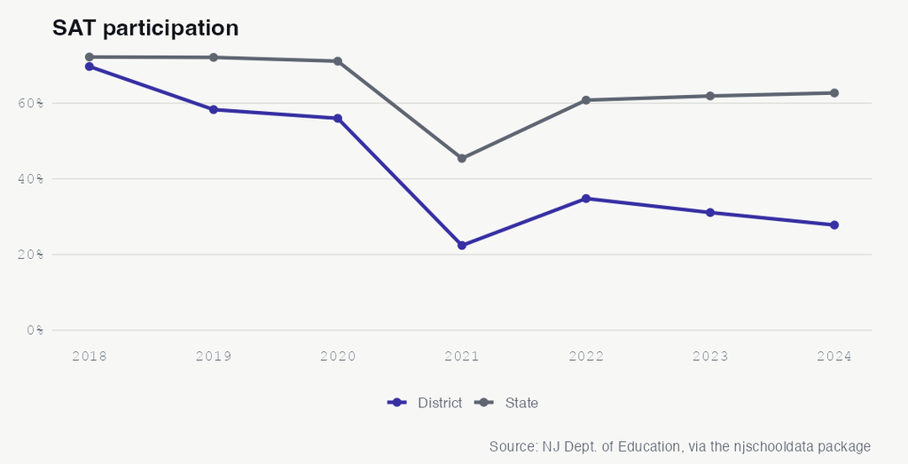

See the underlying data ›

## The Almanac

The full longitudinal record behind the stories above. Every number a reader can check.

### Enrollment (total)

| year | students | yoy | yoy_pct |
| --- | --- | --- | --- |
| 2015 | 10840 | NA | NA |
| 2016 | 10865 | 25 | 0.2 |
| 2017 | 10891 | 26 | 0.2 |
| 2018 | 10689 | -202 | -1.9 |
| 2019 | 10621 | -68 | -0.6 |
| 2020 | 10629 | 8 | 0.1 |
| 2021 | 10411 | -218 | -2.1 |
| 2022 | 10393 | -18 | -0.2 |
| 2023 | 10734 | 341 | 3.3 |
| 2024 | 10904 | 170 | 1.6 |
| 2025 | 10906 | 2 | 0 |
| 2026 | 10673 | -233 | -2.1 |

### Demographic share (%) by year

| end_year | white | black | hispanic | asian | native_american | pacific_islander | multiracial |
| --- | --- | --- | --- | --- | --- | --- | --- |
| 2015 | 34.7 | 4.9 | 53.1 | 7 | 0.1 | 0 | 0.2 |
| 2016 | 34 | 4.6 | 54.1 | 6.9 | 0.1 | 0 | 0.2 |
| 2017 | 32.3 | 4.5 | 55.5 | 7.2 | 0.2 | 0 | 0.3 |
| 2018 | 31.9 | 4.3 | 56 | 7 | 0.4 | 0 | 0.4 |
| 2019 | 30.8 | 4 | 57.1 | 6.9 | 0.5 | 0.1 | 0.6 |
| 2020 | 29.8 | 3.9 | 58.2 | 6.7 | 0.6 | 0.1 | 0.8 |
| 2021 | 29.5 | 4 | 58.3 | 6.4 | 0.7 | 0.1 | 0.9 |
| 2022 | 27.8 | 4 | 59.9 | 6.5 | 0.8 | 0.1 | 1 |
| 2023 | 26.1 | 3.9 | 61.7 | 6.2 | 0.8 | 0.1 | 1.1 |
| 2024 | 26 | 3.7 | 62.4 | 6.1 | 0.7 | 0.1 | 1.1 |
| 2025 | 25.8 | 3.6 | 62.7 | 5.8 | 0.7 | 0.1 | 1.3 |
| 2026 | 25.5 | 3.6 | 63.1 | 5.6 | 0.6 | 0.1 | 1.5 |

### Special populations (LEP, FRL)

| end_year | subgroup | students | pct |
| --- | --- | --- | --- |
| 2015 | lep | 630 | 5.8 |
| 2015 | free_reduced_lunch | 6190 | 57.1 |
| 2016 | lep | 543 | 5.0 |
| 2016 | free_reduced_lunch | 6073 | 55.9 |
| 2017 | lep | 556 | 5.1 |
| 2017 | free_reduced_lunch | 6188 | 56.8 |
| 2018 | lep | 566 | 5.3 |
| 2018 | free_reduced_lunch | 6031 | 56.4 |
| 2019 | lep | 657 | 6.2 |
| 2019 | free_reduced_lunch | 5985 | 56.4 |
| 2020 | lep | 585 | 5.5 |
| 2020 | free_reduced_lunch | 6239 | 58.7 |
| 2021 | lep | 562 | 5.4 |
| 2021 | free_reduced_lunch | 6070 | 58.3 |
| 2022 | lep | 717 | 6.9 |
| 2022 | free_reduced_lunch | 5321 | 51.2 |
| 2023 | lep | 891 | 8.3 |
| 2023 | free_reduced_lunch | 6913 | 64.4 |
| 2024 | lep | 981 | 9.0 |
| 2024 | free_reduced_lunch | 6935 | 63.6 |
| 2025 | lep | 1516 | 13.9 |
| 2025 | free_reduced_lunch | 7122 | 65.3 |
| 2026 | lep | 1441 | 13.5 |
| 2026 | free_reduced_lunch | 7418 | 69.5 |

### Graduation rate 4yr (total)

| year | grad_rate | cohort |
| --- | --- | --- |
| 2020 | 86.3 | 742 |
| 2021 | 84.4 | 777 |
| 2022 | 83.3 | 774 |
| 2023 | 84.3 | 720 |
| 2024 | 86.7 | 803 |
| 2025 | 89.5 | 854 |

### Graduation by subgroup (2025)

| subgroup | grad_rate | cohort |
| --- | --- | --- |
| asian | 97.9 | 47 |
| white | 92.9 | 212 |
| female | 91.9 | NA |
| total | 89.5 | 854 |
| black | 88.6 | 35 |
| economically disadvantaged | 88.0 | 632 |
| hispanic | 87.7 | 551 |
| male | 87.4 | 469 |
| military-connected students | 86.4 | 22 |
| multilingual learners | 80.7 | 135 |
| students with disabilities | 76.6 | 154 |
| american indian | NA | NA |
| migrant students | NA | NA |
| non-binary/undesignated gender | NA | NA |
| students experiencing homelessness | NA | NA |
| students in foster care | NA | NA |
| multiracial | NA | NA |

### NJGPA high-school proficiency (% proficient+)

| year | test | prof_above | valid |
| --- | --- | --- | --- |
| 2023 | ela | 72.2 | 701 |
| 2023 | math | 38.7 | 714 |
| 2024 | ela | 71.6 | 775 |
| 2024 | math | 39.0 | 802 |
| 2025 | ela | 74.2 | 763 |
| 2025 | math | 46.1 | 787 |

### NJGPA ELA by subgroup (2025)

[output not shown]

### NJSLA grades 3-8 proficiency (% proficient+, enrollment-weighted across grades)

| testing_year | test_name | prof |
| --- | --- | --- |
| 2017 | ela | 46.9 |
| 2017 | math | 35.8 |
| 2018 | math | 42.1 |
| 2019 | ela | 50.1 |
| 2019 | math | 41.6 |
| 2022 | ela | 39.2 |
| 2022 | math | 29.8 |
| 2023 | ela | 41.1 |
| 2023 | math | 30.5 |
| 2024 | ela | 38.4 |
| 2024 | math | 32.0 |

### NJSLA ELA proficiency by subgroup (2024, grades 3-8)

| subgroup | prof |
| --- | --- |
| asian | 59.8 |
| non_ed | 49.2 |
| white | 46.7 |
| other | 46.0 |
| FORMER - ML | 44.5 |
| female | 41.3 |
| total_population | 38.4 |
| male | 36.1 |
| black | 35.2 |
| hispanic | 33.0 |
| ed | 31.6 |
| american_indian | 30.0 |
| lep_former | 24.5 |
| MULTILINGUAL LEARNERS | 17.2 |
| lep_current_former | 16.1 |
| special_education | 10.4 |
| sped_accomodations | 9.5 |
| CURRENT - ML | 7.0 |
| lep_current | 6.9 |

### Chronic absenteeism (% chronically absent)

| year | chronic_pct |
| --- | --- |
| 2019 | 11.4 |
| 2021 | 9.3 |
| 2022 | 15.8 |
| 2023 | 18.9 |
| 2024 | 16.6 |

### Disciplinary removals

[output not shown]

### Police notifications (incident counts)

| year | violence | weapons | vandalism | substances | hib | other |
| --- | --- | --- | --- | --- | --- | --- |
| 2019 | 24 | 15 | 1 | 43 | 2 | 2 |
| 2020 | 21 | 4 | 0 | 22 | 0 | 1 |
| 2021 | 3 | 1 | 0 | 9 | 0 | 0 |
| 2022 | 32 | 19 | 0 | 20 | 4 | 1 |
| 2023 | 16 | 9 | 1 | 69 | 2 | 0 |
| 2024 | 12 | 8 | 1 | 73 | 1 | 3 |

### HIB (harassment/intimidation/bullying) investigations

| end_year | alleged | confirmed |
| --- | --- | --- |
| 2019 | 76 | 105 |
| 2020 | 57 | 66 |
| 2021 | 15 | 11 |
| 2022 | 117 | 56 |
| 2023 | 69 | 31 |
| 2024 | 77 | 41 |

### SAT participation (% of grade)

| year | sat_part | state_sat |
| --- | --- | --- |
| 2018 | 69.7 | 72.2 |
| 2019 | 58.3 | 72.1 |
| 2020 | 56 | 71.1 |
| 2021 | 22.4 | 45.4 |
| 2022 | 34.8 | 60.8 |
| 2023 | 31.1 | 61.9 |
| 2024 | 27.8 | 62.7 |

### AP/IB & dual enrollment (% of students)

| year | apib_coursework | apib_exam | ap3_ib4 | state_ap3_ib4 | dual |
| --- | --- | --- | --- | --- | --- |
| 2018 | 20.7 | 14 | 8.3 | 20.5 | 0 |
| 2019 | 20 | 12.9 | 8.2 | 20.7 | 41.9 |
| 2020 | 17.3 | 13.4 | 10.6 | 22.8 | 0 |
| 2021 | 14.6 | 11.8 | NA | 17.9 | 4.5 |
| 2022 | 14.9 | 12.4 | NA | 19.9 | 2 |
| 2023 | 14.4 | 11.2 | NA | 21.3 | 4 |
| 2024 | 13.9 | 13.7 | NA | 23 | 2.2 |

### Special education (raw rows; inspect for classification rate)

| end_year | district_id |
| --- | --- |
| 2024 | 0900 |

### Per-pupil spending (TGES actuals)

| year | per_pupil | rank | ade |
| --- | --- | --- | --- |
| 2014 | 11436 | 5 | 10854 |
| 2015 | 12249 | 13 | 10391 |
| 2016 | 11878 | 5 | 10840 |
| 2017 | 11974 | 3 | 10840 |
| 2018 | 12119 | 3 | 11148 |
| 2019 | 13393 | 5 | 10644 |
| 2020 | 13732 | 8 | 10675 |
| 2021 | 14708 | 17 | 10451 |
| 2022 | 15773 | 21 | 10460 |
| 2023 | 16074 | 15 | 10736 |
| 2024 | 17120 | 20 | 10831 |

### Spending composition shares (2025)

| classroom_share | support_services_share | administration_share | plant_ops_share | food_service_share | extracurricular_share | equipment_share |
| --- | --- | --- | --- | --- | --- | --- |
| 58.7 | 19.5 | 9.1 | 10 | NA | 1.7 | 0.4 |

### Staffing ratios

| end_year | student_teacher_district | student_admin_district | student_counselor_district | student_nurse_district |
| --- | --- | --- | --- | --- |
| 2024 | 12:1 | 162:1 | 262:1 | 647:1 |

Back to top